# DATS 6103 - Individual Project 3 - Hao Ning

# Global Scientific Research Analysis:

# Scientific Articles Publication and Research Expenditure

## Introduction

Science and technology are virtually the driving forces that promote the life quality of people and economic growth of a nation.  
A detailed analysis on scientific research and expenditure would greatly help us to grasp the latest trend in the world.

## Import Packages and Data

```python
from IPython.display import HTML

HTML('''<script>
  function code_toggle() {
    if (code_shown){
      $('div.input').hide('500');
      $('#toggleButton').val('Show Code')
    } else {
      $('div.input').show('500');
      $('#toggleButton').val('Hide Code')
    }
    code_shown = !code_shown
  }

  $( document ).ready(function(){
    code_shown=false;
    $('div.input').hide()
  });
</script>
<form action="javascript:code_toggle()"><input type="submit" id="toggleButton" value="Show Code"></form>''')
```

```python
# import packages
import pandas as pd
import numpy as np
! pip install pycountry
import pycountry
import matplotlib.pyplot as plt
from IPython.display import display
import plotly
import plotly.plotly as py

# plotly sign in
py.sign_in('hning','GVxogtPePwFcvSnJk20b')
print(plotly.__version__)
plotly.offline.init_notebook_mode()


# Import data set of scientific journal articles
# Research and development expenditure (% of GDP)
# GDP ($)
Sci = pd.read_csv('API_IP.JRN.ARTC.SC_DS2_en_csv_v2_10522715.csv', skiprows = 4)
ExpPercent = pd.read_csv('API_GB.XPD.RSDV.GD.ZS_DS2_en_csv_v2_10515258.csv', skiprows = 4)
GDP = pd.read_csv('API_NY.GDP.MKTP.CD_DS2_en_csv_v2_10515210.csv', skiprows = 4)
display(Sci.head())
display(ExpPercent.head())
display(GDP.head())
```

|  | Country Name | Country Code | Indicator Name | Indicator Code | 1960 | 1961 | 1962 | 1963 | 1964 | 1965 | ... | 2010 | 2011 | 2012 | 2013 | 2014 | 2015 | 2016 | 2017 | 2018 | Unnamed: 63 |
| --- | --- | --- | --- | --- | --- | --- | --- | --- | --- | --- | --- | --- | --- | --- | --- | --- | --- | --- | --- | --- | --- |
| 0 | Aruba | ABW | Scientific and technical journal articles | IP.JRN.ARTC.SC | NaN | NaN | NaN | NaN | NaN | NaN | ... | NaN | NaN | NaN | NaN | NaN | NaN | NaN | NaN | NaN | NaN |
| 1 | Afghanistan | AFG | Scientific and technical journal articles | IP.JRN.ARTC.SC | NaN | NaN | NaN | NaN | NaN | NaN | ... | 33.9 | 42.7 | 35.0 | 27.3 | 33.3 | 23.5 | 80.4 | NaN | NaN | NaN |
| 2 | Angola | AGO | Scientific and technical journal articles | IP.JRN.ARTC.SC | NaN | NaN | NaN | NaN | NaN | NaN | ... | 15.2 | 17.8 | 22.4 | 24.1 | 35.7 | 32.9 | 39.1 | NaN | NaN | NaN |
| 3 | Albania | ALB | Scientific and technical journal articles | IP.JRN.ARTC.SC | NaN | NaN | NaN | NaN | NaN | NaN | ... | 140.8 | 165.2 | 214.1 | 359.5 | 360.7 | 269.0 | 191.4 | NaN | NaN | NaN |
| 4 | Andorra | AND | Scientific and technical journal articles | IP.JRN.ARTC.SC | NaN | NaN | NaN | NaN | NaN | NaN | ... | 1.2 | 1.0 | 3.6 | 5.9 | 5.4 | 7.4 | 7.9 | NaN | NaN | NaN |

5 rows × 64 columns

|  | Country Name | Country Code | Indicator Name | Indicator Code | 1960 | 1961 | 1962 | 1963 | 1964 | 1965 | ... | 2010 | 2011 | 2012 | 2013 | 2014 | 2015 | 2016 | 2017 | 2018 | Unnamed: 63 |
| --- | --- | --- | --- | --- | --- | --- | --- | --- | --- | --- | --- | --- | --- | --- | --- | --- | --- | --- | --- | --- | --- |
| 0 | Aruba | ABW | Research and development expenditure (% of GDP) | GB.XPD.RSDV.GD.ZS | NaN | NaN | NaN | NaN | NaN | NaN | ... | NaN | NaN | NaN | NaN | NaN | NaN | NaN | NaN | NaN | NaN |
| 1 | Afghanistan | AFG | Research and development expenditure (% of GDP) | GB.XPD.RSDV.GD.ZS | NaN | NaN | NaN | NaN | NaN | NaN | ... | NaN | NaN | NaN | NaN | NaN | NaN | NaN | NaN | NaN | NaN |
| 2 | Angola | AGO | Research and development expenditure (% of GDP) | GB.XPD.RSDV.GD.ZS | NaN | NaN | NaN | NaN | NaN | NaN | ... | NaN | NaN | NaN | NaN | NaN | NaN | NaN | NaN | NaN | NaN |
| 3 | Albania | ALB | Research and development expenditure (% of GDP) | GB.XPD.RSDV.GD.ZS | NaN | NaN | NaN | NaN | NaN | NaN | ... | NaN | NaN | NaN | NaN | NaN | NaN | NaN | NaN | NaN | NaN |
| 4 | Andorra | AND | Research and development expenditure (% of GDP) | GB.XPD.RSDV.GD.ZS | NaN | NaN | NaN | NaN | NaN | NaN | ... | NaN | NaN | NaN | NaN | NaN | NaN | NaN | NaN | NaN | NaN |

5 rows × 64 columns

|  | Country Name | Country Code | Indicator Name | Indicator Code | 1960 | 1961 | 1962 | 1963 | 1964 | 1965 | ... | 2010 | 2011 | 2012 | 2013 | 2014 | 2015 | 2016 | 2017 | 2018 | Unnamed: 63 |
| --- | --- | --- | --- | --- | --- | --- | --- | --- | --- | --- | --- | --- | --- | --- | --- | --- | --- | --- | --- | --- | --- |
| 0 | Aruba | ABW | GDP (current US$) | NY.GDP.MKTP.CD | NaN | NaN | NaN | NaN | NaN | NaN | ... | 2.390503e+09 | 2.549721e+09 | 2.534637e+09 | 2.581564e+09 | 2.649721e+09 | 2.691620e+09 | 2.646927e+09 | 2.700559e+09 | NaN | NaN |
| 1 | Afghanistan | AFG | GDP (current US$) | NY.GDP.MKTP.CD | 5.377778e+08 | 5.488889e+08 | 5.466667e+08 | 7.511112e+08 | 8.000000e+08 | 1.006667e+09 | ... | 1.585657e+10 | 1.780429e+10 | 1.990732e+10 | 2.056107e+10 | 2.048489e+10 | 1.990711e+10 | 1.904636e+10 | 1.954398e+10 | NaN | NaN |
| 2 | Angola | AGO | GDP (current US$) | NY.GDP.MKTP.CD | NaN | NaN | NaN | NaN | NaN | NaN | ... | 8.379950e+10 | 1.117897e+11 | 1.280529e+11 | 1.367099e+11 | 1.457122e+11 | 1.161936e+11 | 1.011239e+11 | 1.221238e+11 | NaN | NaN |
| 3 | Albania | ALB | GDP (current US$) | NY.GDP.MKTP.CD | NaN | NaN | NaN | NaN | NaN | NaN | ... | 1.192696e+10 | 1.289087e+10 | 1.231978e+10 | 1.277628e+10 | 1.322825e+10 | 1.138693e+10 | 1.188368e+10 | 1.303854e+10 | NaN | NaN |
| 4 | Andorra | AND | GDP (current US$) | NY.GDP.MKTP.CD | NaN | NaN | NaN | NaN | NaN | NaN | ... | 3.355695e+09 | 3.442063e+09 | 3.164615e+09 | 3.281585e+09 | 3.350736e+09 | 2.811489e+09 | 2.877312e+09 | 3.012914e+09 | NaN | NaN |

5 rows × 64 columns

## Data Cleaning

```python
from IPython.display import HTML

HTML('''<script>
  function code_toggle() {
    if (code_shown){
      $('div.input').hide('500');
      $('#toggleButton').val('Show Code')
    } else {
      $('div.input').show('500');
      $('#toggleButton').val('Hide Code')
    }
    code_shown = !code_shown
  }

  $( document ).ready(function(){
    code_shown=false;
    $('div.input').hide()
  });
</script>
<form action="javascript:code_toggle()"><input type="submit" id="toggleButton" value="Show Code"></form>''')
```

```python
# drop the region/area that are not in pycountry based on the Country Code
# get the country_code and take a look at length and first 5 code
country_code = []
for country in pycountry.countries:
    country_code.append(country.alpha_3)

len(country_code)

# set index as country code, drop region and area (that are not in country_code), leaving only countries in dataframe
Sci.new= Sci.set_index('Country Code')
# creat a droplist
droplist = []
for x in Sci.new.index:
    if x not in country_code:
        droplist.append(x)

print('number of code that will be dropped:',len(droplist))
Sci.new = Sci.new.drop(droplist)
Sci.new.shape
Sci.new.tail()

# rename, reset index
Sci.new = Sci.new.rename(columns={'Country Name':'Country'}).reset_index().set_index('Country').rename(columns={'Country Code':'Code'})
Sci.new.head()


# cleaning on Exp and GDP
ExpPercent.new= ExpPercent.set_index('Country Code')
ExpPercent.new = ExpPercent.new.drop(droplist)
ExpPercent.new = ExpPercent.new.rename(columns={'Country Name':'Country'}).reset_index().set_index('Country').rename(columns={'Country Code':'Code'})
display(ExpPercent.new.shape)
display(ExpPercent.new.head())

GDP.new= GDP.set_index('Country Code')
GDP.new = GDP.new.drop(droplist)
GDP.new = GDP.new.rename(columns={'Country Name':'Country'}).reset_index().set_index('Country').rename(columns={'Country Code':'Code'})
display(GDP.new.shape)
display(GDP.new.head())

# find out if there's any different name in the country index
name1 = []
for x in Sci.new.index:
    if x not in ExpPercent.new.index:
        name1.append(x)

name2 = []
for y in ExpPercent.new.index:
    if y not in GDP.new.index:
        name2.append(y)

name3 = []
for z in GDP.new.index:
    if z not in Sci.new.index:
        name3.append(z)

print(name1, name2, name3)


# rename as Macedonia, make them consistent
Sci.new.rename(index={'North Macedonia':'Macedonia'}, inplace=True)
ExpPercent.new.rename(index={'Macedonia, FYR':'Macedonia'}, inplace=True)
GDP.new.rename(index={'Macedonia, FYR':'Macedonia'}, inplace=True)

# data cleaning, drop columns (Sci have no data before 2003), fillna, changed data type to int
# unit for Sci is thousand (k), so times 1000 to get the real number
Sci_clean = Sci.new.loc[:,'2003':'2016'].fillna(0).astype('int64')

Sci_clean['Code'] = Sci.new.loc[:,'Code']

Sci_clean.head()

# cleaning for Exp, GDP
ExpPercent_clean = ExpPercent.new.loc[:,'2003':'2016'].fillna(0)
GDP_clean = GDP.new.loc[:,'2003':'2016'].fillna(0)

# Calculte the Expenditure in $
Exp = ExpPercent_clean*GDP_clean

# add code column, Exp is the same as GDP
ExpPercent_clean['Code'] = ExpPercent.new.loc[:,'Code']
GDP_clean['Code'] = GDP.new.loc[:,'Code']
Exp['Code'] = GDP.new.loc[:,'Code']

display(ExpPercent_clean.head())
display(GDP_clean.head())
display(Exp.head())
```

```
number of code that will be dropped: 49
```

```
(215, 63)
```

| Country | Code | Indicator Name | Indicator Code | 1960 | 1961 | 1962 | 1963 | 1964 | 1965 | 1966 | ... | 2010 | 2011 | 2012 | 2013 | 2014 | 2015 | 2016 | 2017 | 2018 | Unnamed: 63 |
| --- | --- | --- | --- | --- | --- | --- | --- | --- | --- | --- | --- | --- | --- | --- | --- | --- | --- | --- | --- | --- | --- |
| Aruba | ABW | Research and development expenditure (% of GDP) | GB.XPD.RSDV.GD.ZS | NaN | NaN | NaN | NaN | NaN | NaN | NaN | ... | NaN | NaN | NaN | NaN | NaN | NaN | NaN | NaN | NaN | NaN |
| Afghanistan | AFG | Research and development expenditure (% of GDP) | GB.XPD.RSDV.GD.ZS | NaN | NaN | NaN | NaN | NaN | NaN | NaN | ... | NaN | NaN | NaN | NaN | NaN | NaN | NaN | NaN | NaN | NaN |
| Angola | AGO | Research and development expenditure (% of GDP) | GB.XPD.RSDV.GD.ZS | NaN | NaN | NaN | NaN | NaN | NaN | NaN | ... | NaN | NaN | NaN | NaN | NaN | NaN | NaN | NaN | NaN | NaN |
| Albania | ALB | Research and development expenditure (% of GDP) | GB.XPD.RSDV.GD.ZS | NaN | NaN | NaN | NaN | NaN | NaN | NaN | ... | NaN | NaN | NaN | NaN | NaN | NaN | NaN | NaN | NaN | NaN |
| Andorra | AND | Research and development expenditure (% of GDP) | GB.XPD.RSDV.GD.ZS | NaN | NaN | NaN | NaN | NaN | NaN | NaN | ... | NaN | NaN | NaN | NaN | NaN | NaN | NaN | NaN | NaN | NaN |

5 rows × 63 columns

```
(215, 63)
```

| Country | Code | Indicator Name | Indicator Code | 1960 | 1961 | 1962 | 1963 | 1964 | 1965 | 1966 | ... | 2010 | 2011 | 2012 | 2013 | 2014 | 2015 | 2016 | 2017 | 2018 | Unnamed: 63 |
| --- | --- | --- | --- | --- | --- | --- | --- | --- | --- | --- | --- | --- | --- | --- | --- | --- | --- | --- | --- | --- | --- |
| Aruba | ABW | GDP (current US$) | NY.GDP.MKTP.CD | NaN | NaN | NaN | NaN | NaN | NaN | NaN | ... | 2.390503e+09 | 2.549721e+09 | 2.534637e+09 | 2.581564e+09 | 2.649721e+09 | 2.691620e+09 | 2.646927e+09 | 2.700559e+09 | NaN | NaN |
| Afghanistan | AFG | GDP (current US$) | NY.GDP.MKTP.CD | 5.377778e+08 | 5.488889e+08 | 5.466667e+08 | 7.511112e+08 | 8.000000e+08 | 1.006667e+09 | 1.400000e+09 | ... | 1.585657e+10 | 1.780429e+10 | 1.990732e+10 | 2.056107e+10 | 2.048489e+10 | 1.990711e+10 | 1.904636e+10 | 1.954398e+10 | NaN | NaN |
| Angola | AGO | GDP (current US$) | NY.GDP.MKTP.CD | NaN | NaN | NaN | NaN | NaN | NaN | NaN | ... | 8.379950e+10 | 1.117897e+11 | 1.280529e+11 | 1.367099e+11 | 1.457122e+11 | 1.161936e+11 | 1.011239e+11 | 1.221238e+11 | NaN | NaN |
| Albania | ALB | GDP (current US$) | NY.GDP.MKTP.CD | NaN | NaN | NaN | NaN | NaN | NaN | NaN | ... | 1.192696e+10 | 1.289087e+10 | 1.231978e+10 | 1.277628e+10 | 1.322825e+10 | 1.138693e+10 | 1.188368e+10 | 1.303854e+10 | NaN | NaN |
| Andorra | AND | GDP (current US$) | NY.GDP.MKTP.CD | NaN | NaN | NaN | NaN | NaN | NaN | NaN | ... | 3.355695e+09 | 3.442063e+09 | 3.164615e+09 | 3.281585e+09 | 3.350736e+09 | 2.811489e+09 | 2.877312e+09 | 3.012914e+09 | NaN | NaN |

5 rows × 63 columns

```
['North Macedonia'] [] ['Macedonia, FYR']
```

| Country | 2003 | 2004 | 2005 | 2006 | 2007 | 2008 | 2009 | 2010 | 2011 | 2012 | 2013 | 2014 | 2015 | 2016 | Code |
| --- | --- | --- | --- | --- | --- | --- | --- | --- | --- | --- | --- | --- | --- | --- | --- |
| Aruba | 0.0 | 0.0 | 0.0 | 0.0 | 0.00000 | 0.00000 | 0.0 | 0.0 | 0.0 | 0.0 | 0.0 | 0.0 | 0.0 | 0.0 | ABW |
| Afghanistan | 0.0 | 0.0 | 0.0 | 0.0 | 0.00000 | 0.00000 | 0.0 | 0.0 | 0.0 | 0.0 | 0.0 | 0.0 | 0.0 | 0.0 | AFG |
| Angola | 0.0 | 0.0 | 0.0 | 0.0 | 0.00000 | 0.00000 | 0.0 | 0.0 | 0.0 | 0.0 | 0.0 | 0.0 | 0.0 | 0.0 | AGO |
| Albania | 0.0 | 0.0 | 0.0 | 0.0 | 0.08737 | 0.15412 | 0.0 | 0.0 | 0.0 | 0.0 | 0.0 | 0.0 | 0.0 | 0.0 | ALB |
| Andorra | 0.0 | 0.0 | 0.0 | 0.0 | 0.00000 | 0.00000 | 0.0 | 0.0 | 0.0 | 0.0 | 0.0 | 0.0 | 0.0 | 0.0 | AND |

| Country | 2003 | 2004 | 2005 | 2006 | 2007 | 2008 | 2009 | 2010 | 2011 | 2012 | 2013 | 2014 | 2015 | 2016 | Code |
| --- | --- | --- | --- | --- | --- | --- | --- | --- | --- | --- | --- | --- | --- | --- | --- |
| Aruba | 2.021229e+09 | 2.228492e+09 | 2.330726e+09 | 2.424581e+09 | 2.615084e+09 | 2.745251e+09 | 2.498883e+09 | 2.390503e+09 | 2.549721e+09 | 2.534637e+09 | 2.581564e+09 | 2.649721e+09 | 2.691620e+09 | 2.646927e+09 | ABW |
| Afghanistan | 4.515559e+09 | 5.226779e+09 | 6.209138e+09 | 6.971286e+09 | 9.747880e+09 | 1.010923e+10 | 1.243909e+10 | 1.585657e+10 | 1.780429e+10 | 1.990732e+10 | 2.056107e+10 | 2.048489e+10 | 1.990711e+10 | 1.904636e+10 | AFG |
| Angola | 1.781271e+10 | 2.355205e+10 | 3.697092e+10 | 5.238101e+10 | 6.526645e+10 | 8.853861e+10 | 7.030716e+10 | 8.379950e+10 | 1.117897e+11 | 1.280529e+11 | 1.367099e+11 | 1.457122e+11 | 1.161936e+11 | 1.011239e+11 | AGO |
| Albania | 5.611496e+09 | 7.184686e+09 | 8.052074e+09 | 8.896073e+09 | 1.067732e+10 | 1.288135e+10 | 1.204421e+10 | 1.192696e+10 | 1.289087e+10 | 1.231978e+10 | 1.277628e+10 | 1.322825e+10 | 1.138693e+10 | 1.188368e+10 | ALB |
| Andorra | 2.398646e+09 | 2.935659e+09 | 3.255789e+09 | 3.543257e+09 | 4.016972e+09 | 4.007353e+09 | 3.660531e+09 | 3.355695e+09 | 3.442063e+09 | 3.164615e+09 | 3.281585e+09 | 3.350736e+09 | 2.811489e+09 | 2.877312e+09 | AND |

| Country | 2003 | 2004 | 2005 | 2006 | 2007 | 2008 | 2009 | 2010 | 2011 | 2012 | 2013 | 2014 | 2015 | 2016 | Code |
| --- | --- | --- | --- | --- | --- | --- | --- | --- | --- | --- | --- | --- | --- | --- | --- |
| Aruba | 0.0 | 0.0 | 0.0 | 0.0 | 0.000000e+00 | 0.000000e+00 | 0.0 | 0.0 | 0.0 | 0.0 | 0.0 | 0.0 | 0.0 | 0.0 | ABW |
| Afghanistan | 0.0 | 0.0 | 0.0 | 0.0 | 0.000000e+00 | 0.000000e+00 | 0.0 | 0.0 | 0.0 | 0.0 | 0.0 | 0.0 | 0.0 | 0.0 | AFG |
| Angola | 0.0 | 0.0 | 0.0 | 0.0 | 0.000000e+00 | 0.000000e+00 | 0.0 | 0.0 | 0.0 | 0.0 | 0.0 | 0.0 | 0.0 | 0.0 | AGO |
| Albania | 0.0 | 0.0 | 0.0 | 0.0 | 9.328778e+08 | 1.985274e+09 | 0.0 | 0.0 | 0.0 | 0.0 | 0.0 | 0.0 | 0.0 | 0.0 | ALB |
| Andorra | 0.0 | 0.0 | 0.0 | 0.0 | 0.000000e+00 | 0.000000e+00 | 0.0 | 0.0 | 0.0 | 0.0 | 0.0 | 0.0 | 0.0 | 0.0 | AND |

## Overview of Scientific Research Publication

```python
from IPython.display import HTML

HTML('''<script>
  function code_toggle() {
    if (code_shown){
      $('div.input').hide('500');
      $('#toggleButton').val('Show Code')
    } else {
      $('div.input').show('500');
      $('#toggleButton').val('Hide Code')
    }
    code_shown = !code_shown
  }

  $( document ).ready(function(){
    code_shown=false;
    $('div.input').hide()
  });
</script>
<form action="javascript:code_toggle()"><input type="submit" id="toggleButton" value="Show Code"></form>''')
```

```python
# For a given year, map the world Sci using plotly for year
# plotly.offline.init_notebook_mode()

def mapper(year):
    data = [dict(type='choropleth',
                 locations=Sci_clean['Code'],
                 z=Sci_clean[str(year)],
                 autocolorscale = True,
                 text=Sci_clean.index,
                 hoverinfo='text+z',
                 marker=dict(line=dict(color='rgb(180,180,180)', width=0.5)),
                 colorbar=dict(title='Number of Scientific Articles in' + str(year)))]

    layout = dict(title='World Number of Scientific Articles in' + str(year),
                  geo = dict(showcoastlines=False, showframe=False, projection={'type': 'equirectangular'}))

    fig = dict(data=data, layout=layout)
    return py.iplot(fig, validate=False, filename="geomap-world_Sci")
```

```python
mapper(2003)
```

[interactive chart not shown]

```python
mapper(2016)
```

[interactive chart not shown]

```python
from IPython.display import HTML

HTML('''<script>
  function code_toggle() {
    if (code_shown){
      $('div.input').hide('500');
      $('#toggleButton').val('Show Code')
    } else {
      $('div.input').show('500');
      $('#toggleButton').val('Hide Code')
    }
    code_shown = !code_shown
  }

  $( document ).ready(function(){
    code_shown=false;
    $('div.input').hide()
  });
</script>
<form action="javascript:code_toggle()"><input type="submit" id="toggleButton" value="Show Code"></form>''')
```

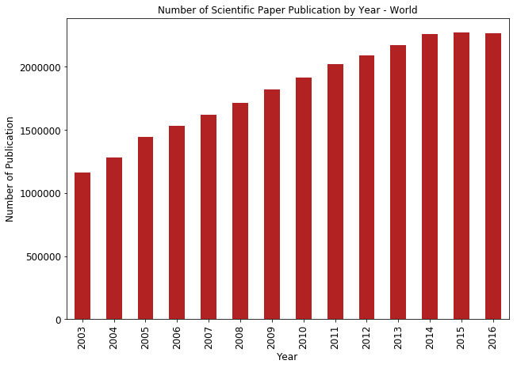

```python
# plot world scientific paper publication, 2003 to 2016 (no data before 2003 )
Sci_world = Sci_clean.loc[:,'2003':'2016'].sum()

Sci_world.plot(kind='bar',figsize=(10,7), fontsize=12, color = 'firebrick')

plt.title('Number of Scientific Paper Publication by Year - World', fontsize=12)
plt.xlabel('Year', fontsize=12)
plt.ylabel('Number of Publication', fontsize=12)

plt.show()
```

The total number of publication in increasing from 2003 and plateaued after 2014.

## Top Scientific Research Countries

```python
from IPython.display import HTML

HTML('''<script>
  function code_toggle() {
    if (code_shown){
      $('div.input').hide('500');
      $('#toggleButton').val('Show Code')
    } else {
      $('div.input').show('500');
      $('#toggleButton').val('Hide Code')
    }
    code_shown = !code_shown
  }

  $( document ).ready(function(){
    code_shown=false;
    $('div.input').hide()
  });
</script>
<form action="javascript:code_toggle()"><input type="submit" id="toggleButton" value="Show Code"></form>''')
```

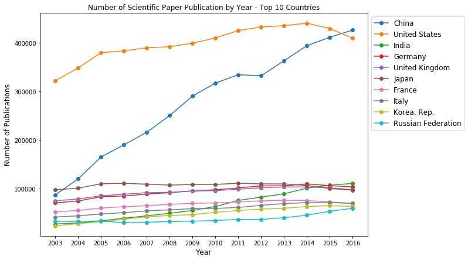

```python
# Sci top 10 countries, sort by 2016
Sci_clean.top = Sci_clean.sort_values('2016', ascending=False).drop('Code', axis=1).head(10)
Sci_clean.top

# plot number of publications by year

plt.figure(figsize=(10,7))

for i in Sci_clean.top.index:
    plt.plot(Sci_clean.top.loc[i,:], marker = 'o')

plt.xlabel('Year', fontsize=12)
plt.ylabel('Number of Publications', fontsize=12)
plt.legend(bbox_to_anchor=(1, 1), fontsize=12)
plt.title('Number of Scientific Paper Publication by Year - Top 10 Countries', fontsize=12)

plt.show()
```

```python
# for a given year and dataframe, get the top 10 countries

def topten(year,data,total=10):
    df = data[str(year)]
    top = df.sort_values(ascending=False)
    top = top.reset_index().head(total)
    top.index = top.index + 1
    return top


# for a given year and dataframe, make a pie chart of the top 10 and the rest countries

def PiePlot(year, data):
    df = data[str(year)]
    top = df.sort_values(ascending=False)
    top = top.reset_index()
    top.index = top.index + 1
    others = top[10:].sum()[1]
    top = top[:10]
    top.loc[11] = ['All Other Countries', others]

    countryPlot = top[str(year)].plot.pie(subplots=True,
                                     autopct='%0.2f',
                                     fontsize=12,
                                     figsize=(10,10),
                                     legend=False,
                                     labels=top['Country'],
                                     shadow=False,
                                     explode=(0.15,0,0,0,0,0,0,0,0,0,0),
                                     startangle=90)
    plt.show()
```

```python
topten(2003,Sci_clean)
```

|  | Country | 2003 |
| --- | --- | --- |
| 1 | United States | 321765 |
| 2 | Japan | 97235 |
| 3 | China | 86621 |
| 4 | United Kingdom | 74599 |
| 5 | Germany | 70447 |
| 6 | France | 51757 |
| 7 | Italy | 41207 |
| 8 | Canada | 37695 |
| 9 | Russian Federation | 32329 |
| 10 | Spain | 28887 |

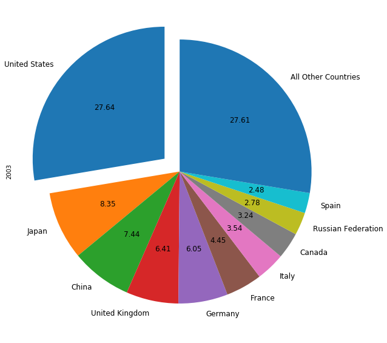

```python
PiePlot(2003,Sci_clean)
```

```python
topten(2016,Sci_clean)
```

|  | Country | 2016 |
| --- | --- | --- |
| 1 | China | 426165 |
| 2 | United States | 408985 |
| 3 | India | 110319 |
| 4 | Germany | 103121 |
| 5 | United Kingdom | 97526 |
| 6 | Japan | 96536 |
| 7 | France | 69430 |
| 8 | Italy | 69125 |
| 9 | Korea, Rep. | 63063 |
| 10 | Russian Federation | 59133 |

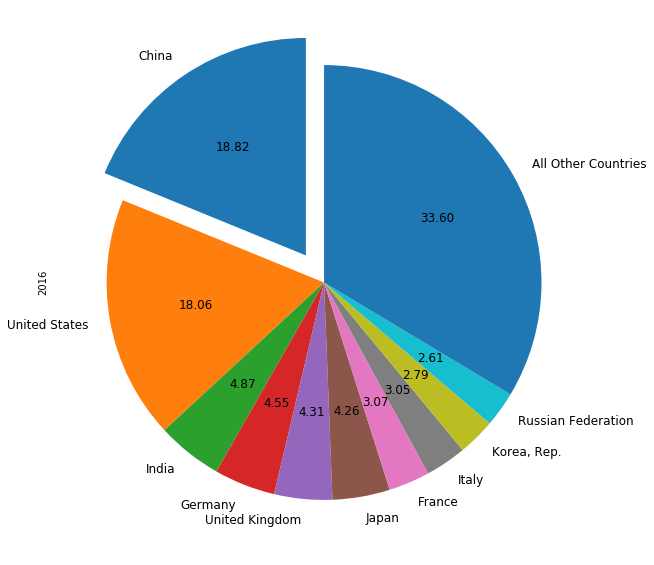

```python
PiePlot(2016,Sci_clean)
```

From 2003 to 2016:  
USA have a dominating number of publications in 2003.  
China climbed from 3rd place to top rank, the number of publication is similar to USA in 2016.  
Japan's rank is 2nd then falling to 6th.  
Korea, Rep. is new to top10.  
Other than the top 10 countries, the rest countries also showed a higher share of total publication. It's a indication that all coutries are putting more efforts in scientific research.

## Change of Number of Publication of Top Countries in Absolute and Percentage

```python
from IPython.display import HTML

HTML('''<script>
  function code_toggle() {
    if (code_shown){
      $('div.input').hide('500');
      $('#toggleButton').val('Show Code')
    } else {
      $('div.input').show('500');
      $('#toggleButton').val('Hide Code')
    }
    code_shown = !code_shown
  }

  $( document ).ready(function(){
    code_shown=false;
    $('div.input').hide()
  });
</script>
<form action="javascript:code_toggle()"><input type="submit" id="toggleButton" value="Show Code"></form>''')
```

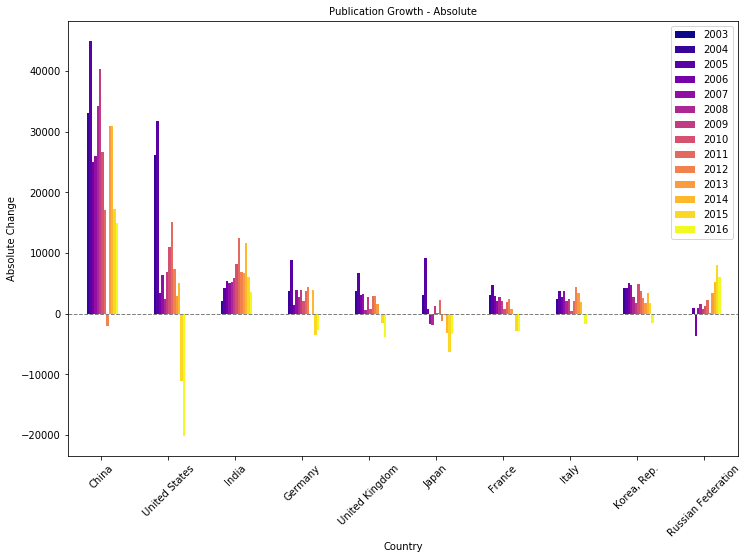

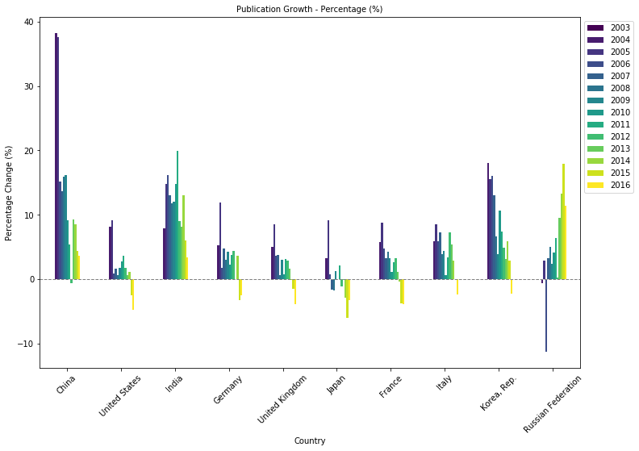

```python
# absolute change
Sci_change = Sci_clean.top.diff(axis=1).fillna(value=0)

Sci_change

# percentage change
Sci_pchange = (Sci_clean.top.pct_change(axis=1) * 100).fillna(value=0)

Sci_pchange

# make the absolute and percentage change plot

Sci_change.plot(kind='bar', colormap='plasma', figsize=(12,8), rot=45, fontsize=10)
plt.xlabel('Country', fontsize=10)
plt.ylabel('Absolute Change', fontsize=10)
plt.legend(bbox_to_anchor=(1, 1), fontsize=10)
plt.axhline(0, linestyle='dashed',linewidth=1, color='grey')
plt.title('Publication Growth - Absolute', fontsize=10)


Sci_pchange.plot(kind='bar',colormap= 'viridis', figsize=(12,8), rot=45, fontsize=10)
plt.xlabel('Country', fontsize=10)
plt.ylabel('Percentage Change (%)', fontsize=10)
plt.legend(bbox_to_anchor=(1, 1), fontsize=10)
plt.axhline(0, linestyle='dashed',linewidth=1, color='grey')
plt.title('Publication Growth - Percentage (%)', fontsize=10)

plt.show()
```

China and USA showed greatest growth in absolute number overall. However, there's a drop obersered for recent years for USA.  
Also, India and Korea, Rep. have steady increase.

China showed fastest growing in percentage. Followed by India, Korea, Rep.and Russia.

## Research Expenditure Analysis

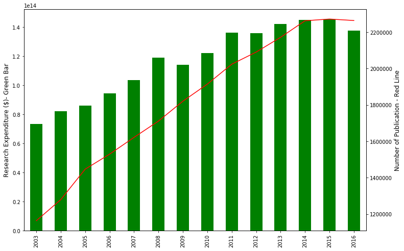

```python
# global total expenditure comparing with publication
# bar-line plot, bar expenditure, line publication
fig, ax1 = plt.subplots(figsize=(12,8))

df1 = Exp.drop('Code', axis=1).sum()
df2 = Sci_world

ax1=df1.plot(kind='bar',width = 0.5, color = 'g')
ax2 = ax1.twinx()
ax2=df2.plot(color='r')

ax1.set_ylabel('Research Expenditure ($)- Green Bar', fontsize=12)
ax2.set_ylabel('Number of Publication - Red Line', fontsize=12)

plt.show()
```

The total expenditure keep increasing (with small fluctuations) from 2003 and reached stagnant after 2013.

The overall trend of publication and research expenditure coincides.

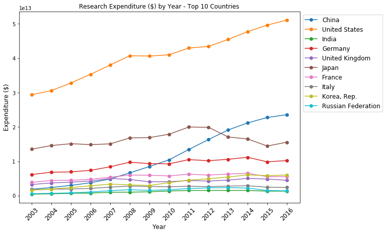

```python
# get top country index with top publication, find the data in Exp($)
Exp.top = Exp.loc[Sci_clean.top.index].drop('Code', axis=1)
Exp.top

# There're a few 0 in the dataframe (India), let's fill it with the value of previous column
Exp.fill= Exp.replace(0, np.nan).ffill(axis=1)
Exp.top.fill = Exp.top.replace(0, np.nan).ffill(axis=1)
Exp.top.fill

# plot the expenditure for top countries by year

plt.figure(figsize=(10,7))

for i in Exp.top.fill.index:
    plt.plot(Exp.top.fill.loc[i,:], marker = 'o')

plt.xlabel('Year', fontsize=12)
plt.xticks(rotation=45, fontsize=12)
plt.ylabel('Expenditure ($)', fontsize=12)
plt.legend(bbox_to_anchor=(1, 1), fontsize=12)
plt.title('Research Expenditure ($) by Year - Top 10 Countries', fontsize=12)

plt.show()
```

```python
from IPython.display import HTML

HTML('''<script>
  function code_toggle() {
    if (code_shown){
      $('div.input').hide('500');
      $('#toggleButton').val('Show Code')
    } else {
      $('div.input').show('500');
      $('#toggleButton').val('Hide Code')
    }
    code_shown = !code_shown
  }

  $( document ).ready(function(){
    code_shown=false;
    $('div.input').hide()
  });
</script>
<form action="javascript:code_toggle()"><input type="submit" id="toggleButton" value="Show Code"></form>''')
```

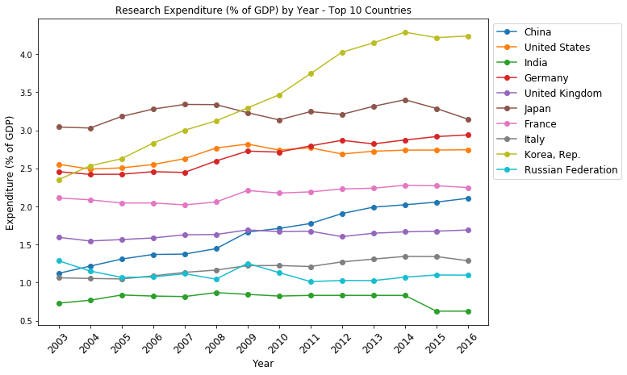

```python
# Expenditure (% of GDP) of top countries,ffill India
ExpPercent.top = ExpPercent_clean.loc[Sci_clean.top.index].drop('Code', axis=1)
ExpPercent.top.fill = ExpPercent.top.replace(0, np.nan).ffill(axis=1)
ExpPercent.top.fill

# plot the expenditure (% of GDP) for top countries by year

plt.figure(figsize=(10,7))

for i in ExpPercent.top.fill.index:
    plt.plot(ExpPercent.top.fill.loc[i,:], marker = 'o')

plt.xlabel('Year', fontsize=12)
plt.xticks(rotation=45, fontsize=12)
plt.ylabel('Expenditure (% of GDP)', fontsize=12)
plt.legend(bbox_to_anchor=(1, 1), fontsize=12)
plt.title('Research Expenditure (% of GDP) by Year - Top 10 Countries', fontsize=12)

plt.show()
```

```python
topten(2003,Exp)
```

|  | Country | 2003 |
| --- | --- | --- |
| 1 | United States | 2.938524e+13 |
| 2 | Japan | 1.352791e+13 |
| 3 | Germany | 6.155585e+12 |
| 4 | France | 3.885568e+12 |
| 5 | United Kingdom | 3.248672e+12 |
| 6 | China | 1.860137e+12 |
| 7 | Canada | 1.762256e+12 |
| 8 | Italy | 1.666937e+12 |
| 9 | Korea, Rep. | 1.600245e+12 |
| 10 | Sweden | 1.196753e+12 |

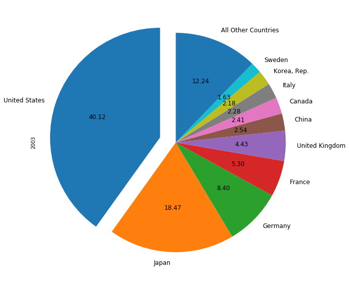

```python
PiePlot(2003,Exp)
```

```python
topten(2016,Exp)
```

|  | Country | 2016 |
| --- | --- | --- |
| 1 | United States | 5.110891e+13 |
| 2 | China | 2.357640e+13 |
| 3 | Japan | 1.557338e+13 |
| 4 | Germany | 1.022295e+13 |
| 5 | Korea, Rep. | 5.996944e+12 |
| 6 | France | 5.541030e+12 |
| 7 | United Kingdom | 4.480891e+12 |
| 8 | Canada | 2.473154e+12 |
| 9 | Italy | 2.391130e+12 |
| 10 | Sweden | 1.674516e+12 |

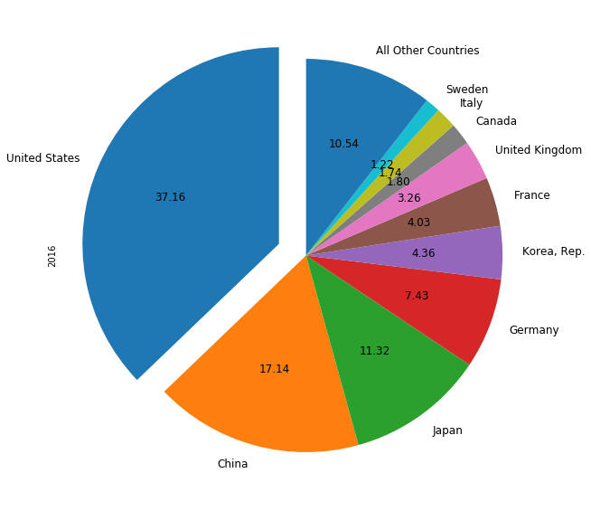

```python
PiePlot(2016,Exp)
```

Both USA and China raised their research expenditure in terms of the absolute amount.  
Interestingly, the growth rate (slope) of this two countries coincides with each other.  
Korea showed steady increase.  
The rest countries don't have extraordinary change in expenditure. USA have an dominating research expenditure percentage.

Note: India has few missing value because of the data set, the value is filled by previous column.

**Japan** is maintaining a very high expenditure % of GDP among all the countries, up to 3%.  
Followed by USA and Gemany around 2.5-2.8%.  
**Korea** significantly raised the expenditure % to more than 4%.  
China also increased the percentage from 1 to 2 %.

## Correlation between Publication and Research Expenditure

```python
from IPython.display import HTML

HTML('''<script>
  function code_toggle() {
    if (code_shown){
      $('div.input').hide('500');
      $('#toggleButton').val('Show Code')
    } else {
      $('div.input').show('500');
      $('#toggleButton').val('Hide Code')
    }
    code_shown = !code_shown
  }

  $( document ).ready(function(){
    code_shown=false;
    $('div.input').hide()
  });
</script>
<form action="javascript:code_toggle()"><input type="submit" id="toggleButton" value="Show Code"></form>''')
```

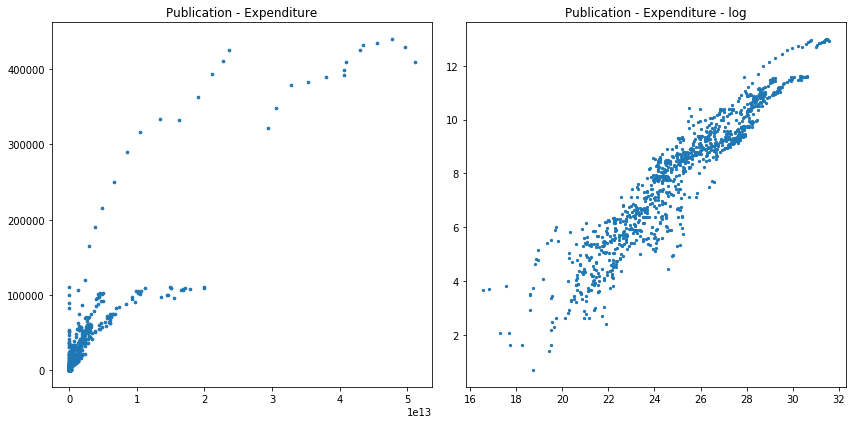

```python
# scatter plot of Expenditure vs publications
# scatterf plot of log number

fig, ax = plt.subplots(1,2,figsize=(12,6))

x1=Exp.drop('Code', axis=1)
y1=Sci_clean.drop('Code', axis=1)

x2=np.log(Exp.drop('Code', axis=1))
y2=np.log(Sci_clean.drop('Code', axis=1))

plt.subplot(1,2,1)
plt.scatter(x1,y1, s=7)
plt.title('Publication - Expenditure')

plt.subplot(1,2,2)
plt.scatter(x2,y2, s=5)
plt.title('Publication - Expenditure - log')

plt.tight_layout()
plt.show()
```

Obviously, a positive correlation is observed that a higher research expenditure would lead to more publications.

For the actually number plot, we can see the data points are splitting apart, it will be interesting to further explore the 'productivity'.

For the log plot, a pretty clear linear relation is observed.  
Also, for higher expenditure, the data points are more concentrated, while for lower expenditure, data points are more scattered.

Overall, countries with higher expenditure will have more publications.

## Most Productive Countries

```python
from IPython.display import HTML

HTML('''<script>
  function code_toggle() {
    if (code_shown){
      $('div.input').hide('500');
      $('#toggleButton').val('Show Code')
    } else {
      $('div.input').show('500');
      $('#toggleButton').val('Hide Code')
    }
    code_shown = !code_shown
  }

  $( document ).ready(function(){
    code_shown=false;
    $('div.input').hide()
  });
</script>
<form action="javascript:code_toggle()"><input type="submit" id="toggleButton" value="Show Code"></form>''')
```

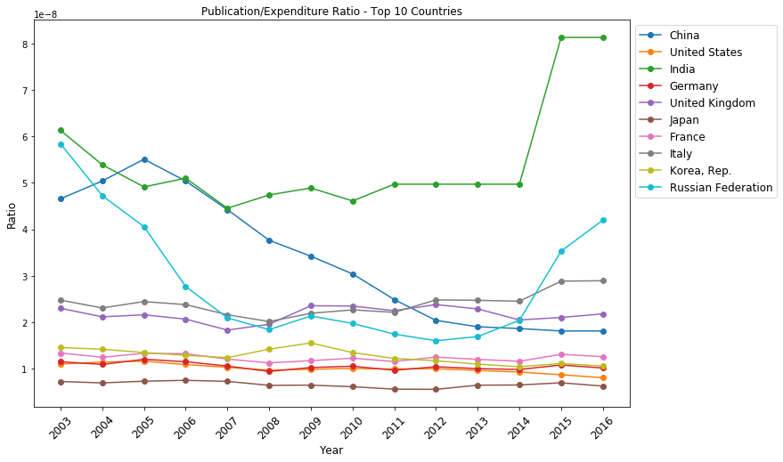

```python
# calcultate publication/expenditure ratio, higher ratio indicates the country is more productive
# India have missing value, serveal year will be inf after calculation, replace using ffill
ratio = Sci_clean.top/Exp.top
ratio.fill = ratio.replace(np.inf, np.nan).ffill(axis=1)
ratio.fill

# plot the ratio
plt.figure(figsize=(12,8))

for i in ratio.fill.index:
    plt.plot(ratio.fill.loc[i,:], marker = 'o')

plt.xlabel('Year', fontsize=12)
plt.xticks(rotation=45, fontsize=12)
plt.ylabel('Ratio', fontsize=12)
plt.legend(bbox_to_anchor=(1, 1), fontsize=12)
plt.title('Publication/Expenditure Ratio - Top 10 Countries', fontsize=12)

plt.show()
```

India showed highest productivity overall.  
China have a very high productivity ratio at 2003 to 2005 then decreased and stablized, still among top 5.  
Russia showed a "U" shape curve.  
The rest countries showed similar ratio.

We can see that, the developing countries showed a great rise in publication output. Productivity is one aspect of scientific research, on the other hand, developed countries probably are more dominating in citations.

Note: India has few missing value because of the data set, the value is filled by previous column.

## Summary

- From 2003 to 2016, the number of global publication keep increasing then plateaued after 2014.
- USA was the only giant in publication in 2003, while in 2016, China climbed up to top and these two countries became the flagships.
- USA has an dominating expenditure in scientific research
- Japan, USA and Germany are maintaining a high research expenditure % of GDP (2.5-3%).
- Korea dramatically increased their expenditure % ( >4% in 2016) and became top10.
- Positive correlation is observed for publication/expenditure, but indicating differences in 'productivity'
- India, Russia and China are the most 'productive' countries

## References

- Jeff Tollefson. "China declared world’s largest producer of scientific articles", Nature, Volume 553, Issue 7689, pp. 390 (2018). DOI: 10.1038/d41586-018-00927-4
- Lee-Roy Chetty. 2012. "The Role of Science and Technology in the Developing World in the 21st Century", URL: https://ieet.org/index.php/IEET2/more/chetty20121003
- Karen E. White, Carol Robbins, Beethika Khan, and Christina Freyman. 2017. "Science and Engineering Publication Output Trends: 2014 Shows Rise of Developing Country Output while Developed Countries Dominate Highly Cited Publications", URL: https://www.nsf.gov/statistics/2018/nsf18300/

**Project 3 Complete, thank you!**